DS 6030 | Fall 2023 | University of Virginia

# Homework #4: Risk and Classification

Author

*Jacqui Unciano (jdu5sq)

Published

September 26, 2023

This is an **independent assignment**. Do not discuss or work with classmates.

# Required R packages and Directories

```r
dir_data= 'https://mdporter.github.io/DS6030/data/' # data directory
library(glmnet)    # for glmnet() functions
library(yardstick) # for evaluation metrics
library(tidyverse) # functions for data manipulation
```

# Crime Linkage

Crime linkage attempts to determine if a set of unsolved crimes share a common offender. *Pairwise* crime linkage is the more simple task of deciding if two crimes share a common offender; it can be considered a binary classification problem. The linkage training data has 8 evidence variables that measure the similarity between a pair of crimes:

- `spatial` is the spatial distance between the crimes
- `temporal` is the fractional time (in days) between the crimes
- `tod` and `dow` are the differences in time of day and day of week between the crimes
- `LOC`, `POA,` and `MOA` are binary with a 1 corresponding to a match (type of property, point of entry, method of entry)
- `TIMERANGE` is the time between the earliest and latest possible times the crime could have occurred (because the victim was away from the house during the crime).
- The response variable indicates if the crimes are linked ($y=1$) or unlinked ($y=0$).

These problems use the [linkage-train](https://mdporter.github.io/DS6030/data/linkage_train.csv) and [linkage-test](https://mdporter.github.io/DS6030/data/linkage_test.csv) datasets (click on links for data).

## Load Crime Linkage Data

**Solution**

```r
data_train = read_csv("C:/Users/Jacqueline/Downloads/linkage_train.csv")
data_test = read_csv("C:/Users/Jacqueline/Downloads/linkage_test.csv")
```

# Problem 1: Penalized Regression for Crime Linkage

## a. Fit a penalized *linear regression* model to predict linkage.

Use an elastic net penalty (including lasso and ridge) (your choice).

- Report the value of $\alpha \in [0, 1]$ used
- Report the value of $\lambda$ used
- Report the estimated coefficients

**Solution**

```r
X = glmnet::makeX(select(data_train, -y), data_test)
X.train = X$x
X.test = X$xtest
Y.train = data_train$y
```

```r
alpha = 0
enet_lin = cv.glmnet(X.train, Y.train, alpha = alpha)
lamb_lin = enet_lin$lambda.min
print(lamb_lin)
```

```
[1] 0.00233
```

```r
coef(enet_lin, s=lamb_lin)
```

```
9 x 1 sparse Matrix of class "dgCMatrix"
                   s1
(Intercept)  0.092629
spatial     -0.002319
temporal    -0.000155
tod         -0.002213
dow         -0.005795
LOC          0.042628
POA          0.009321
MOA          0.007297
TIMERANGE    0.000025
```

## b. Fit a penalized *logistic regression* model to predict linkage.

Use an elastic net penalty (including lasso and ridge) (your choice).

- Report the value of $\alpha \in [0, 1]$ used
- Report the value of $\lambda$ used
- Report the estimated coefficients

**Solution**

```r
enet_log = cv.glmnet(X.train, Y.train, alpha = alpha, family = "binomial")
lamb_log = enet_log$lambda.min
print(lamb_log)
```

[output not shown]

```r
coef(enet_log, s=lamb_log)
```

```
9 x 1 sparse Matrix of class "dgCMatrix"
                   s1
(Intercept) -0.836883
spatial     -0.172424
temporal    -0.009663
tod         -0.102776
dow         -0.241770
LOC          1.361673
POA          0.418216
MOA          0.231825
TIMERANGE    0.000542
```

## c. ROC curve: training data

Produce one plot that has the ROC curves, using the *training data*, for both models (from part a and b). Use color and/or linetype to distinguish between models and include a legend.

**Solution**

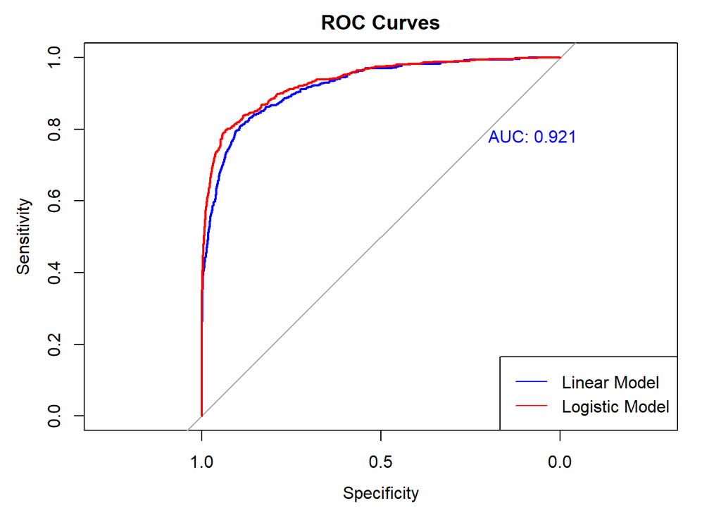

```r
# Load the pROC package
library(pROC)
# Predict probabilities for both models on the training data
set.seed(2345)
pred_lin = predict(enet_lin, newx = X.train, s = lamb_lin, type = "response")
pred_log = predict(enet_log, newx = X.train, s = lamb_log, type = "response")

# Calculate ROC curves for both models
roc_lin = roc(Y.train, pred_lin)
roc_log = roc(Y.train, pred_log)
# Create a plot with ROC curves, color, and a legend
plot(roc_lin, col = "blue", main = "ROC Curves", print.auc = TRUE, print.auc.x = 0.2, print.auc.y = 0.8)
lines(roc_log, col = "red")
legend("bottomright", legend = c("Linear Model", "Logistic Model"), col = c("blue", "red"), lty = 1)
```

## d. ROC curve: resampling estimate

Recreate the ROC curve from the penalized logistic regression model using repeated hold-out data. The following steps will guide you:

- Fix $\alpha=.75$
- Run the following steps 25 times:
  1. Hold out 500 observations
  2. Use the remaining observations to estimate $\lambda$ using 10-fold CV
  3. Predict the probability of linkage for the 500 hold-out observations
  4. Store the predictions and hold-out labels
- Combine the results and produce the hold-out based ROC curve from all of the hold-out data. I’m looking for a single ROC curve using the predictions for all 12,500 (25 x 500) observations rather than 25 different curves.
- Note: by estimating $\lambda$ each iteration, we are incorporating the uncertainty present in estimating that tuning parameter.

**Solution**

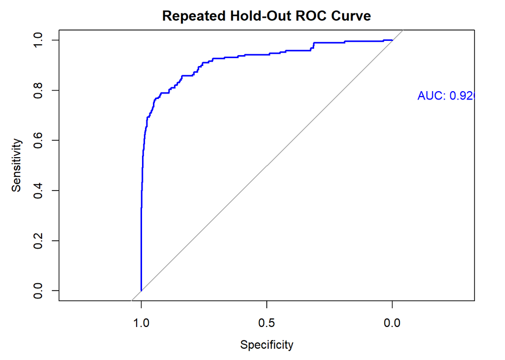

```r
alpha = 0.75
nobs = 500


labels = c()
preds = c()

# Repeated hold-out and model fitting
for (i in 1:25) {
  samp = sample(1:nrow(data_train), size = nobs)
  ho_data = data_train[samp, ]
  train_data = data_train[-samp, ]

  X = glmnet::makeX(select(train_data, -y), data_test)
  X.train = X$x
  X.test = X$xtest
  Y.train = train_data$y

  # Estimate lambda using 10-fold cross-validation
  cvfit = cv.glmnet(X.train, Y.train,
                     alpha = alpha,
                     family = "binomial",
                     nfolds = 10)

  # Fit penalized logistic regression model with estimated lambda
  mod = glmnet(X.train, Y.train,
                alpha = alpha,
                lambda = cvfit$lambda.min,
                family = "binomial")

  # Predict probabilities on the hold-out data
  pred = predict(mod, newx=as.matrix(ho_data[,-9]), type = "response")

  # Store true labels and predictions
  labels = c(labels, ho_data[,9])
  preds = c(preds, pred)
}

# Create a single ROC curve from all hold-out data
labels = unlist(labels, recursive = FALSE)
roc_curve = roc(labels, preds)
# Plot the ROC curve
plot(roc_curve, main = "Repeated Hold-Out ROC Curve", print.auc = TRUE,
     col = "blue", print.auc.x = -0.1, print.auc.y = 0.8)
```

## e. Contest Part 1: Predict the estimated *probability* of linkage.

Predict the estimated *probability* of linkage for the test data (using any model).

- Submit a .csv file (ensure comma separated format) named `lastname_firstname_1.csv` that includes the column named **p** that is your estimated posterior probability. We will use automated evaluation, so the format must be exact.
- You are free to any model (even ones we haven’t yet covered in the course).
- You are free to use any data transformation or feature engineering.
- You will receive credit for a proper submission; the top five scores will receive 2 bonus points.
- Your probabilities will be evaluated with respect to the mean negative Bernoulli log-likelihood (known as the average *log-loss* metric):
  $$L = - \frac{1}{M} \sum_{i=1}^m [y_i \log \, \hat{p}_i + (1 - y_i) \log \, (1 - \hat{p}_i)]$$
  where $M$ is the number of test observations, $\hat{p}_i$ is the prediction for the $i$th test observation, and $y_i \in \{0,1\}$ are the true test set labels.

**Solution**

```r
logmod = glm(y~., data_train, family="binomial")
summary(logmod)
```

```
Call:
glm(formula = y ~ ., family = "binomial", data = data_train)

Coefficients:
             Estimate Std. Error z value Pr(>|z|)
(Intercept)  0.003414   0.170042    0.02     0.98
spatial     -0.291049   0.013896  -20.94  < 2e-16 ***
temporal    -0.012541   0.000753  -16.65  < 2e-16 ***
tod         -0.114438   0.018860   -6.07  1.3e-09 ***
dow         -0.242150   0.055573   -4.36  1.3e-05 ***
LOC          1.392277   0.109163   12.75  < 2e-16 ***
POA          0.446914   0.107414    4.16  3.2e-05 ***
MOA          0.216912   0.128090    1.69     0.09 .
TIMERANGE    0.000623   0.000140    4.44  9.0e-06 ***
---
Signif. codes:  0 '***' 0.001 '**' 0.01 '*' 0.05 '.' 0.1 ' ' 1

(Dispersion parameter for binomial family taken to be 1)

    Null deviance: 5094.1  on 29999  degrees of freedom
Residual deviance: 2742.4  on 29991  degrees of freedom
AIC: 2760

Number of Fisher Scoring iterations: 9
```

```r
sansMOA = glm(y~spatial+temporal+tod+dow+LOC+POA+TIMERANGE, data_train, family="binomial")
summary(sansMOA)
```

```
Call:
glm(formula = y ~ spatial + temporal + tod + dow + LOC + POA +
    TIMERANGE, family = "binomial", data = data_train)

Coefficients:
             Estimate Std. Error z value Pr(>|z|)
(Intercept)  0.046820   0.167774    0.28     0.78
spatial     -0.291312   0.013895  -20.97  < 2e-16 ***
temporal    -0.012596   0.000753  -16.73  < 2e-16 ***
tod         -0.114511   0.018824   -6.08  1.2e-09 ***
dow         -0.243673   0.055511   -4.39  1.1e-05 ***
LOC          1.401037   0.108963   12.86  < 2e-16 ***
POA          0.463078   0.106896    4.33  1.5e-05 ***
TIMERANGE    0.000621   0.000140    4.43  9.3e-06 ***
---
Signif. codes:  0 '***' 0.001 '**' 0.01 '*' 0.05 '.' 0.1 ' ' 1

(Dispersion parameter for binomial family taken to be 1)

    Null deviance: 5094.1  on 29999  degrees of freedom
Residual deviance: 2745.2  on 29992  degrees of freedom
AIC: 2761

Number of Fisher Scoring iterations: 9
```

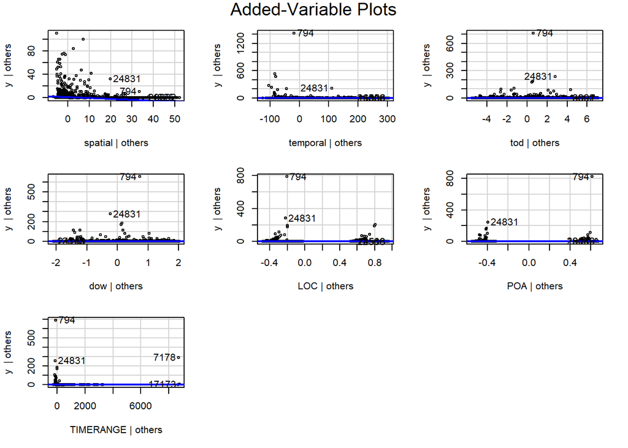

```r
library(car)
car::avPlots(sansMOA)
```

```r
alpha_seq = seq(0,1,0.05)

data_train = data_train %>%
  select(-MOA)
data_test = data_test %>%
  select(-MOA)

X = glmnet::makeX(select(data_train, -y), data_test)
X.train = X$x
X.test = X$xtest
Y.train = data_train$y
Y.test = data_test$y
lambs = data.frame(matrix(ncol=2,nrow=0,
                            dimnames=list(NULL, c("alpha","lambda"))))
for (alpha in alpha_seq){
  lmod = cv.glmnet(X.train, Y.train, alpha = alpha, nfolds=10, family="binomial")
  lambs = rbind(lambs, list(alpha=alpha, lambda=lmod$lambda.min))
}
result = lambs %>%
  filter(lambda==min(lambda))
result
```

```
  alpha   lambda
1  0.05 5.11e-05
```

```r
alpha = 1
finmod = cv.glmnet(X.train, Y.train, alpha = alpha, family="binomial")
lamb_fin = finmod$lambda.min

p = predict(finmod, newx = X.test, s = lamb_fin, type = "response")
```

```r
colnames(p) = c("p")
```

```r
#-- Submit
# write_csv(as.data.frame(p), "C:/Users/Jacqueline/Downloads/unciano_jacqueline_1.csv")
```

## f. Contest Part 2: Predict the *linkage label*.

Predict the linkages for the test data (using any model).

- Submit a .csv file (ensure comma separated format) named `lastname_firstname_2.csv` that includes the column named **linkage** that takes the value of 1 for linked pairs and 0 for unlinked pairs. We will use automated evaluation, so the format must be exact.
- You are free to any model (even ones we haven’t yet covered in the course).
- You are free to use any data transformation or feature engineering.
- Your labels will be evaluated based on total cost, where cost is equal to `1*FP + 8*FN`. This implies that False Negatives (FN) are 8 times as costly as False Positives (FP).
- You will receive credit for a proper submission; the top five scores will receive 2 bonus points. Note: you only will get bonus credit for one of the two contests.

**Solution**

```r
cutoff = 0.1
linkage = ifelse(p >= cutoff, 1, 0)

# write_csv(as.data.frame(linkage), "C:/Users/Jacqueline/Downloads/unciano_jacqueline_2.csv")
```